# Hello Census

maevadevs

12/6/2020

## Import and Setups

Load the tidycensus package into your R session

```r
library(tidyverse)
library(dplyr)
library(tidycensus)
```

Load all our helper functions: - `get_key` is a custom function that allows to load the keys from `.env` - All env settings are stored in `.env` file

```r
source('./helper-functions.R')
envfile = ".env"
```

Get the census api key from the file

```r
api_key = get_key(envfile, "census_api_key")
```

Set Census API Key with `census_api_key()`: This is part of tidycensus

```r
census_api_key(api_key)
```

We could check the API key value with the following

```r
print(Sys.getenv("CENSUS_API_KEY"))
```

## Functions from `tidycensus`

- `get_decennial()`: As default, return data from the 2010 US Census
- `get_acs()`: As default, return data from 2012-2016 ACS. Grants access to the 1-year and 5-year American Community Survey APIs
  - Access to the 1990 (SF1 and SF3) and 2000 (SF3) APIs has been suspended

Obtain and view state populations from the 2010 US Census

```r
state_pop <- get_decennial(geography = "state", variables = "P001001")
head(state_pop)
```

```
## # A tibble: 6 x 4
##   GEOID NAME       variable    value
##   <chr> <chr>      <chr>       <dbl>
## 1 01    Alabama    P001001   4779736
## 2 02    Alaska     P001001    710231
## 3 04    Arizona    P001001   6392017
## 4 05    Arkansas   P001001   2915918
## 5 06    California P001001  37253956
## 6 22    Louisiana  P001001   4533372
```

Obtain and view state median household income from the 2012-2016 American Community Survey (ACS)

```r
state_income <- get_acs(geography = "state", variables = "B19013_001")
head(state_income)
```

```
## # A tibble: 6 x 5
##   GEOID NAME       variable   estimate   moe
##   <chr> <chr>      <chr>         <dbl> <dbl>
## 1 01    Alabama    B19013_001    48486   364
## 2 02    Alaska     B19013_001    76715   894
## 3 04    Arizona    B19013_001    56213   275
## 4 05    Arkansas   B19013_001    45726   350
## 5 06    California B19013_001    71228   217
## 6 08    Colorado   B19013_001    68811   364
```

- Census data comprise thousands of variables available across dozens of geographies
  - Most are available through `tidycensus`
  - But it helps to understand the options
- Census Tract: Only available by state
  - `tidycensus` can help to convert between state and county
- `tidycensus` includes the Census variable ID in the variable column
  - If a user want to supply their own variable name, this can be accomplished with a named vector

Get an ACS dataset for Census tracts in Texas by setting the state

- `B19013_001`: Median household income

```r
tx_income <- get_acs(geography = "tract",
                     variables = "B19013_001",
                     state = "TX")
head(tx_income)
```

```
## # A tibble: 6 x 5
##   GEOID       NAME                                      variable  estimate   moe
##   <chr>       <chr>                                     <chr>        <dbl> <dbl>
## 1 48001950100 Census Tract 9501, Anderson County, Texas B19013_0~    54904  5659
## 2 48001950401 Census Tract 9504.01, Anderson County, T~ B19013_0~    53750 45688
## 3 48001950402 Census Tract 9504.02, Anderson County, T~ B19013_0~    85096  7519
## 4 48001950500 Census Tract 9505, Anderson County, Texas B19013_0~    35057  6270
## 5 48001950600 Census Tract 9506, Anderson County, Texas B19013_0~    52549 16906
## 6 48001950700 Census Tract 9507, Anderson County, Texas B19013_0~    28950  3117
```

Get an ACS dataset for Census tracts in Texas/Travis County by setting the state and county

```r
travis_income <- get_acs(geography="tract",
                     variables="B19013_001",
                     state="TX",
                     county="Travis")
head(travis_income)
```

```
## # A tibble: 6 x 5
##   GEOID       NAME                                    variable   estimate   moe
##   <chr>       <chr>                                   <chr>         <dbl> <dbl>
## 1 48453000101 Census Tract 1.01, Travis County, Texas B19013_001   109267 24775
## 2 48453000102 Census Tract 1.02, Travis County, Texas B19013_001   170500 26804
## 3 48453000203 Census Tract 2.03, Travis County, Texas B19013_001    68611 25794
## 4 48453000204 Census Tract 2.04, Travis County, Texas B19013_001    60882  8821
## 5 48453000205 Census Tract 2.05, Travis County, Texas B19013_001    72266 13845
## 6 48453000206 Census Tract 2.06, Travis County, Texas B19013_001    84673  7407
```

We can also set a better alias name for the variable using a vector

```r
travis_income <- get_acs(geography="tract",
                     variables=c(household_income="B19013_001"),
                     state="TX",
                     county="Travis")
head(travis_income)
```

```
## # A tibble: 6 x 5
##   GEOID       NAME                                variable        estimate   moe
##   <chr>       <chr>                               <chr>              <dbl> <dbl>
## 1 48453000101 Census Tract 1.01, Travis County, ~ household_inco~   109267 24775
## 2 48453000102 Census Tract 1.02, Travis County, ~ household_inco~   170500 26804
## 3 48453000203 Census Tract 2.03, Travis County, ~ household_inco~    68611 25794
## 4 48453000204 Census Tract 2.04, Travis County, ~ household_inco~    60882  8821
## 5 48453000205 Census Tract 2.05, Travis County, ~ household_inco~    72266 13845
## 6 48453000206 Census Tract 2.06, Travis County, ~ household_inco~    84673  7407
```

- By default, tidycensus functions return tidy data frames
- But we can change that to wide dataframe as well
- This is useful when we want to analyze multiple variables

```r
oregon_wide <- get_acs(geography="tract",
                       state="OR",
                       variables=c(hhincome = "B19013_001", medage="B01002_001"),
                       output = "wide")
head(oregon_wide)
```

```
## # A tibble: 6 x 6
##   GEOID      NAME                            hhincomeE hhincomeM medageE medageM
##   <chr>      <chr>                               <dbl>     <dbl>   <dbl>   <dbl>
## 1 410191500~ Census Tract 1500, Douglas Cou~     47034      5521    42.6     3.4
## 2 410192100~ Census Tract 2100, Douglas Cou~     37181      5614    53.2     3.1
## 3 410190100~ Census Tract 100, Douglas Coun~     37679      7446    46.8     7.4
## 4 410190400~ Census Tract 400, Douglas Coun~     41996      6405    55.1     4.4
## 5 410190500~ Census Tract 500.02, Douglas C~     40478      8816    45.9     5.5
## 6 410191000~ Census Tract 1000, Douglas Cou~     49659     12888    42.6     6.7
```

Create a scatterplot

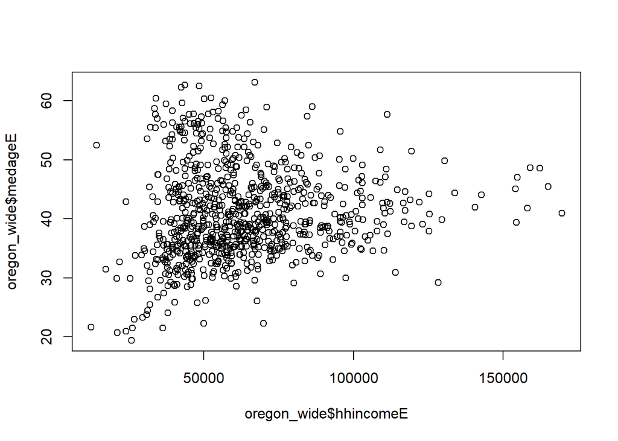

```r
plot(oregon_wide$hhincomeE, oregon_wide$medageE)
```

## Searching for Data with `tidycensus`

- To use `tidycensus` functions, user must supply a vector of census IDs

### Searching for Census Variables

- [Census Reporter](https://censusreporter.org/)
- Built-in tidycensus variable searching:

### `load_variables(year, dataset, cache?)`

- Return can be explored with `tidyverse`
- Return columns:
  - `name`: Census Variable ID
  - `label`: Variable description for human-readable
  - `concept`: General group to which the variable corresponds

Load variables

```r
v16 <- load_variables(year=2016,
                      dataset='acs5', # or acs5/profile, sf3...
                      cache=TRUE)
head(v16)
```

```
## # A tibble: 6 x 3
##   name       label                           concept
##   <chr>      <chr>                           <chr>
## 1 B00001_001 Estimate!!Total                 UNWEIGHTED SAMPLE COUNT OF THE POP~
## 2 B00002_001 Estimate!!Total                 UNWEIGHTED SAMPLE HOUSING UNITS
## 3 B01001_001 Estimate!!Total                 SEX BY AGE
## 4 B01001_002 Estimate!!Total!!Male           SEX BY AGE
## 5 B01001_003 Estimate!!Total!!Male!!Under 5~ SEX BY AGE
## 6 B01001_004 Estimate!!Total!!Male!!5 to 9 ~ SEX BY AGE
```

Filter with `tidyverse`

```r
B19001 <- filter(v16, str_detect(name, "B19001"))
head(B19001)
```

```
## # A tibble: 6 x 3
##   name     label                   concept
##   <chr>    <chr>                   <chr>
## 1 B19001_~ Estimate!!Total         HOUSEHOLD INCOME IN THE PAST 12 MONTHS (IN 2~
## 2 B19001_~ Estimate!!Total!!Less ~ HOUSEHOLD INCOME IN THE PAST 12 MONTHS (IN 2~
## 3 B19001_~ Estimate!!Total!!$10,0~ HOUSEHOLD INCOME IN THE PAST 12 MONTHS (IN 2~
## 4 B19001_~ Estimate!!Total!!$15,0~ HOUSEHOLD INCOME IN THE PAST 12 MONTHS (IN 2~
## 5 B19001_~ Estimate!!Total!!$20,0~ HOUSEHOLD INCOME IN THE PAST 12 MONTHS (IN 2~
## 6 B19001_~ Estimate!!Total!!$25,0~ HOUSEHOLD INCOME IN THE PAST 12 MONTHS (IN 2~
```

We can also filter by a different column

```r
# Use public transportation to search for related variables
public_trans <- filter(v16, str_detect(label,
                        fixed("public transportation",
                              ignore_case = TRUE)
                        ))
head(public_trans)
```

```
## # A tibble: 6 x 3
##   name     label                                     concept
##   <chr>    <chr>                                     <chr>
## 1 B08006_~ Estimate!!Total!!Public transportation (~ SEX OF WORKERS BY MEANS OF~
## 2 B08006_~ Estimate!!Total!!Public transportation (~ SEX OF WORKERS BY MEANS OF~
## 3 B08006_~ Estimate!!Total!!Public transportation (~ SEX OF WORKERS BY MEANS OF~
## 4 B08006_~ Estimate!!Total!!Public transportation (~ SEX OF WORKERS BY MEANS OF~
## 5 B08006_~ Estimate!!Total!!Public transportation (~ SEX OF WORKERS BY MEANS OF~
## 6 B08006_~ Estimate!!Total!!Public transportation (~ SEX OF WORKERS BY MEANS OF~
```

### Typical Variable Format

`[Table ID]_[Column Number]_[Row Number][Variable Type]`

- The variable type is optional for `tidycensus`
  - `tidycensus` returns both `E` (Estimate) and `M` (Margin of Error) by default
  - Suffixes are only showing up when returning in wide-format

## Visualizing Census Data With `ggplot2`